# Project #5_AllLife Credit Card Customer Segmentation

### AllLife Credit Card Customer Segmentation

Background: AllLife Bank wants to focus on its credit card customer base in the next financial year. They have been advised by their marketing research team, that the penetration in the market can be improved. Based on this input, the Marketing team proposes to run personalised campaigns to target new customers as well as upsell to existing customers. Another insight from the market research was that the customers perceive the support services of the back poorly. Based on this, the Operations team wants to upgrade the service delivery model, to ensure that customers queries are resolved faster. Head of Marketing and Head of Delivery both decide to reach out to the Data Science team for help. Objective: To identify different segments in the existing customer based on their spending patterns as well as past interaction with the bank. Key Questions:

1. How many different segments of customers are there?
2. How are these segments different from each other?
3. What are your recommendations to the bank on how to better market to and service these customers? Data Description:

Data is of various customers of a bank with their credit limit, the total number of credit cards the customer has, and different channels through which customer has contacted the bank for any queries, different channels include visiting the bank, online and through a call centre.

Steps to follow:

1. Perform univariate analysis on the data to better understand the variables at your disposal and to get an idea about the no of clusters. Perform EDA, create visualizations to explore data. (10 marks)
2. Properly comment on the codes, provide explanations of the steps taken in the notebook and conclude your insights from the graphs. (5 marks)
3. Execute K-means clustering use elbow plot and analyse clusters using boxplot (10 marks)
4. Execute hierarchical clustering (with different linkages) with the help of dendrogram and cophenetic coeff. Analyse clusters formed using boxplot (15 marks)
5. Calculateaveragesilhouettescoreforbothmethods.(5marks)
6. Compare K-means clusters with Hierarchical clusters. (5 marks)
7. Analysis the clusters formed, tell us how is one cluster different from another and answer all the key questions. (10 marks)

### Perform univariate analysis on the data to better understand the variables at your disposal and to get an idea about the no of clusters. Perform EDA, create visualizations to explore data.

```python
import numpy as np
import pandas as pd
import matplotlib.pyplot as plt
import seaborn as sns
```

```python
sns.set(color_codes=True) # adds a nice background to the graphs
%matplotlib inline
```

Read the datasets into dataframes

```python
ccc_df = pd.read_excel('Credit Card Customer Data.xlsx')
#read the excel data into pandas dataframe named ccc_df
```

```python
ccc_df.head()#show first five rows of dataframe
```

|  | Sl_No | Customer Key | Avg_Credit_Limit | Total_Credit_Cards | Total_visits_bank | Total_visits_online | Total_calls_made |
| --- | --- | --- | --- | --- | --- | --- | --- |
| 0 | 1 | 87073 | 100000 | 2 | 1 | 1 | 0 |
| 1 | 2 | 38414 | 50000 | 3 | 0 | 10 | 9 |
| 2 | 3 | 17341 | 50000 | 7 | 1 | 3 | 4 |
| 3 | 4 | 40496 | 30000 | 5 | 1 | 1 | 4 |
| 4 | 5 | 47437 | 100000 | 6 | 0 | 12 | 3 |

```python
ccc_df.shape
# get the number of rows and columns of the dataset
```

```
(660, 7)
```

```python
ccc_df.isnull().values.any() #Check if there is any null entry in the data; the answer is no
```

```
False
```

```python
ccc_df.describe().transpose()
#get descriptive statistics of the numerical variables
```

|  | count | mean | std | min | 25% | 50% | 75% | max |
| --- | --- | --- | --- | --- | --- | --- | --- | --- |
| Sl_No | 660.0 | 330.500000 | 190.669872 | 1.0 | 165.75 | 330.5 | 495.25 | 660.0 |
| Customer Key | 660.0 | 55141.443939 | 25627.772200 | 11265.0 | 33825.25 | 53874.5 | 77202.50 | 99843.0 |
| Avg_Credit_Limit | 660.0 | 34574.242424 | 37625.487804 | 3000.0 | 10000.00 | 18000.0 | 48000.00 | 200000.0 |
| Total_Credit_Cards | 660.0 | 4.706061 | 2.167835 | 1.0 | 3.00 | 5.0 | 6.00 | 10.0 |
| Total_visits_bank | 660.0 | 2.403030 | 1.631813 | 0.0 | 1.00 | 2.0 | 4.00 | 5.0 |
| Total_visits_online | 660.0 | 2.606061 | 2.935724 | 0.0 | 1.00 | 2.0 | 4.00 | 15.0 |
| Total_calls_made | 660.0 | 3.583333 | 2.865317 | 0.0 | 1.00 | 3.0 | 5.00 | 10.0 |

```python
zero_percent = ccc_df[ccc_df == 0].count(axis=0)*100/ccc_df.shape[0]
zero_df = pd.DataFrame(zero_percent,columns=['Percent of zero values'])
zero_df.index.name = 'Feature Name'
zero_df
```

| Feature Name | Percent of zero values |
| --- | --- |
| Sl_No | 0.000000 |
| Customer Key | 0.000000 |
| Avg_Credit_Limit | 0.000000 |
| Total_Credit_Cards | 0.000000 |
| Total_visits_bank | 15.151515 |
| Total_visits_online | 21.818182 |
| Total_calls_made | 14.696970 |

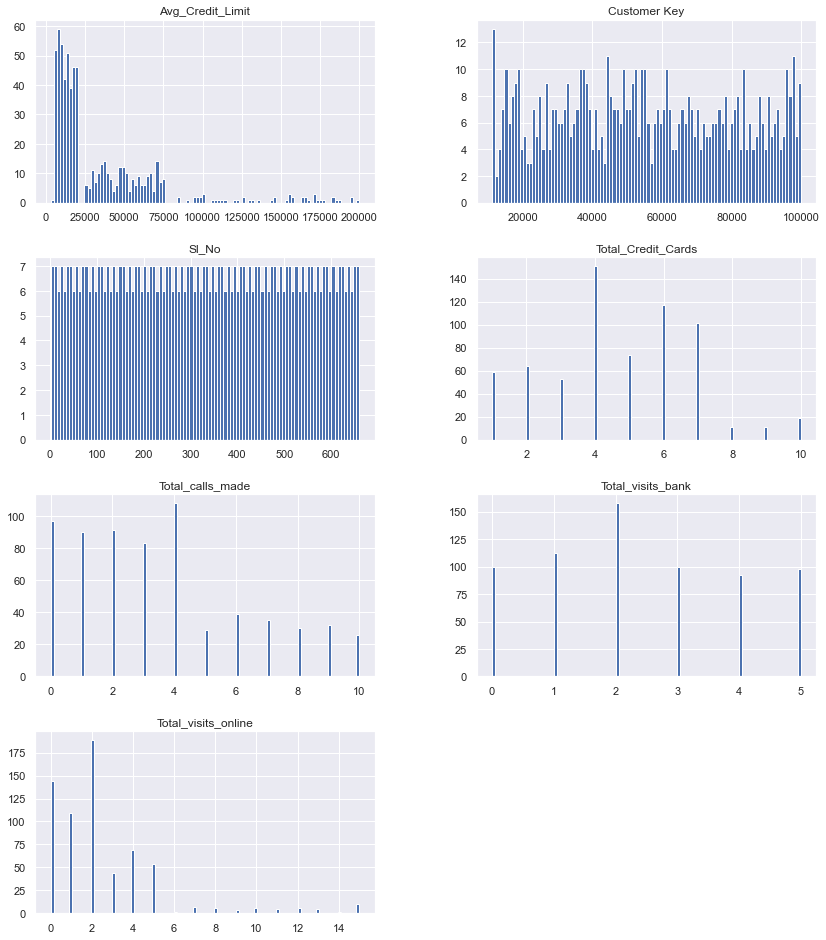

```python
columns = list(ccc_df)[:] # get all the colomn names
ccc_df[columns].hist(stacked=False, bins=100, figsize=(14,60), layout=(14,2));
#plot histograms of each column with numerical values
```

```python
ccc_df['Total_Credit_Cards'].unique()
```

```
array([ 2,  3,  7,  5,  6,  4,  1,  9,  8, 10])
```

```python
ccc_df['Total_calls_made'].unique()
```

```
array([ 0,  9,  4,  3,  8,  2,  1,  7,  5,  6, 10])
```

```python
ccc_df['Total_visits_bank'].unique()
```

```
array([1, 0, 2, 5, 3, 4])
```

```python
ccc_df['Total_visits_online'].unique()
```

```
array([ 1, 10,  3, 12, 11,  2,  5,  4,  0, 14,  7, 13, 15,  6,  8,  9])
```

```python
ccc_df.corr()
```

| Feature Name | Sl_No | Customer Key | Avg_Credit_Limit | Total_Credit_Cards | Total_visits_bank | Total_visits_online | Total_calls_made |
| --- | --- | --- | --- | --- | --- | --- | --- |
| Sl_No | 1.000000 | 0.052886 | 0.677962 | 0.739329 | 0.406438 | 0.033916 | -0.684125 |
| Customer Key | 0.052886 | 1.000000 | 0.068604 | -0.010281 | -0.000560 | 0.022506 | 0.005968 |
| Avg_Credit_Limit | 0.677962 | 0.068604 | 1.000000 | 0.608860 | -0.100312 | 0.551385 | -0.414352 |
| Total_Credit_Cards | 0.739329 | -0.010281 | 0.608860 | 1.000000 | 0.315796 | 0.167758 | -0.651251 |
| Total_visits_bank | 0.406438 | -0.000560 | -0.100312 | 0.315796 | 1.000000 | -0.551861 | -0.506016 |
| Total_visits_online | 0.033916 | 0.022506 | 0.551385 | 0.167758 | -0.551861 | 1.000000 | 0.127299 |
| Total_calls_made | -0.684125 | 0.005968 | -0.414352 | -0.651251 | -0.506016 | 0.127299 | 1.000000 |

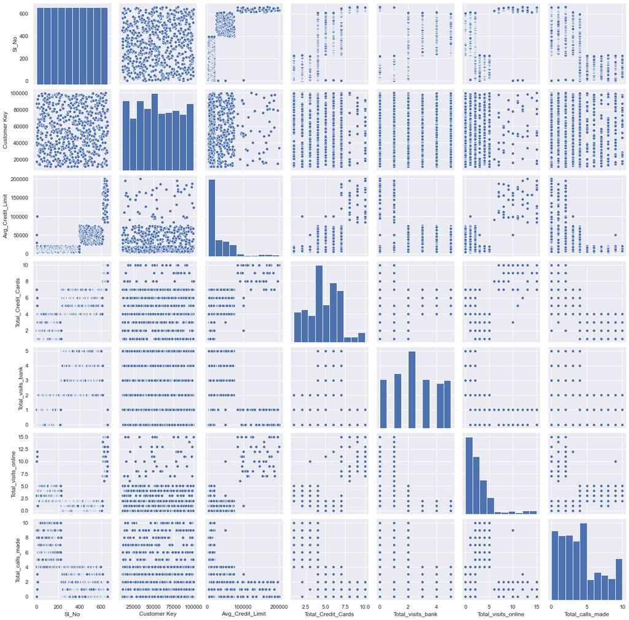

```python
sns.pairplot(ccc_df);
```

Scale the data for clustering

```python
from sklearn.cluster import KMeans
from scipy.stats import zscore
#Remove customer ID before carrying out custering
creditAttrK=ccc_df.iloc[:,2:]
creditAttrK.head()
```

| Feature Name | Avg_Credit_Limit | Total_Credit_Cards | Total_visits_bank | Total_visits_online | Total_calls_made |
| --- | --- | --- | --- | --- | --- |
| 0 | 100000 | 2 | 1 | 1 | 0 |
| 1 | 50000 | 3 | 0 | 10 | 9 |
| 2 | 50000 | 7 | 1 | 3 | 4 |
| 3 | 30000 | 5 | 1 | 1 | 4 |
| 4 | 100000 | 6 | 0 | 12 | 3 |

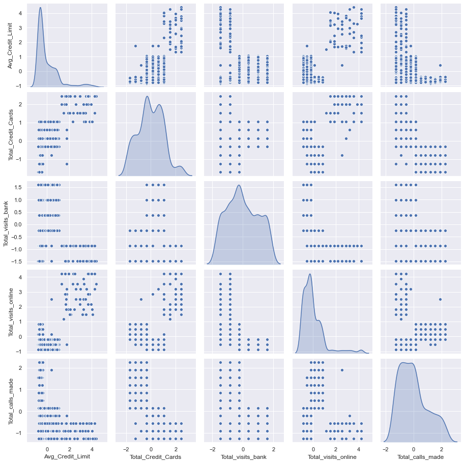

```python
#scale the data before the clustering
creditScaledK=creditAttrK.apply(zscore)
sns.pairplot(creditScaledK,diag_kind='kde')
```

## Execute K-means clustering use elbow plot and analyse clusters using boxplot

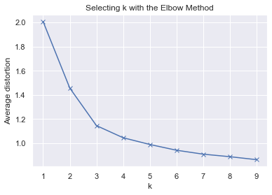

```python
from scipy.spatial.distance import cdist
clusters=range(1,10)
meanDistortions=[]

for k in clusters:
    model=KMeans(n_clusters=k)
    model.fit(creditScaledK)
    prediction=model.predict(creditScaledK)
    meanDistortions.append(sum(np.min(cdist(creditScaledK, model.cluster_centers_, 'euclidean'), axis=1)) / creditScaledK.shape[0])


plt.plot(clusters, meanDistortions, 'bx-')
plt.xlabel('k')
plt.ylabel('Average distortion')
plt.title('Selecting k with the Elbow Method')
```

The bend is clearly as sharp at 3, but still let us look at 3 clusters and 5 clusters

```python
# Let us first start with K = 3
creditScaledK3=creditScaledK
final_model3=KMeans(3)
final_model3.fit(creditScaledK3)
prediction3=final_model3.predict(creditScaledK3)

#Append the prediction
ccc_df["GROUP"] = prediction3
creditScaledK3["GROUP"] = prediction3
print("Groups Assigned : \n")
ccc_df.head()
```

```
Groups Assigned :
```

| Feature Name | Sl_No | Customer Key | Avg_Credit_Limit | Total_Credit_Cards | Total_visits_bank | Total_visits_online | Total_calls_made | GROUP |
| --- | --- | --- | --- | --- | --- | --- | --- | --- |
| 0 | 1 | 87073 | 100000 | 2 | 1 | 1 | 0 | 1 |
| 1 | 2 | 38414 | 50000 | 3 | 0 | 10 | 9 | 0 |
| 2 | 3 | 17341 | 50000 | 7 | 1 | 3 | 4 | 1 |
| 3 | 4 | 40496 | 30000 | 5 | 1 | 1 | 4 | 1 |
| 4 | 5 | 47437 | 100000 | 6 | 0 | 12 | 3 | 2 |

```python
creditClustK = ccc_df.groupby(['GROUP'])
creditClustK.mean()
```

| Feature Name GROUP | Sl_No | Customer Key | Avg_Credit_Limit | Total_Credit_Cards | Total_visits_bank | Total_visits_online | Total_calls_made |
| --- | --- | --- | --- | --- | --- | --- | --- |
| 0 | 117.857143 | 55239.830357 | 12174.107143 | 2.410714 | 0.933036 | 3.553571 | 6.870536 |
| 1 | 417.528497 | 54881.329016 | 33782.383420 | 5.515544 | 3.489637 | 0.981865 | 2.000000 |
| 2 | 611.280000 | 56708.760000 | 141040.000000 | 8.740000 | 0.600000 | 10.900000 | 1.080000 |

```
array([[<matplotlib.axes._subplots.AxesSubplot object at 0x1a18bb5c10>,
      dtype=object)
```

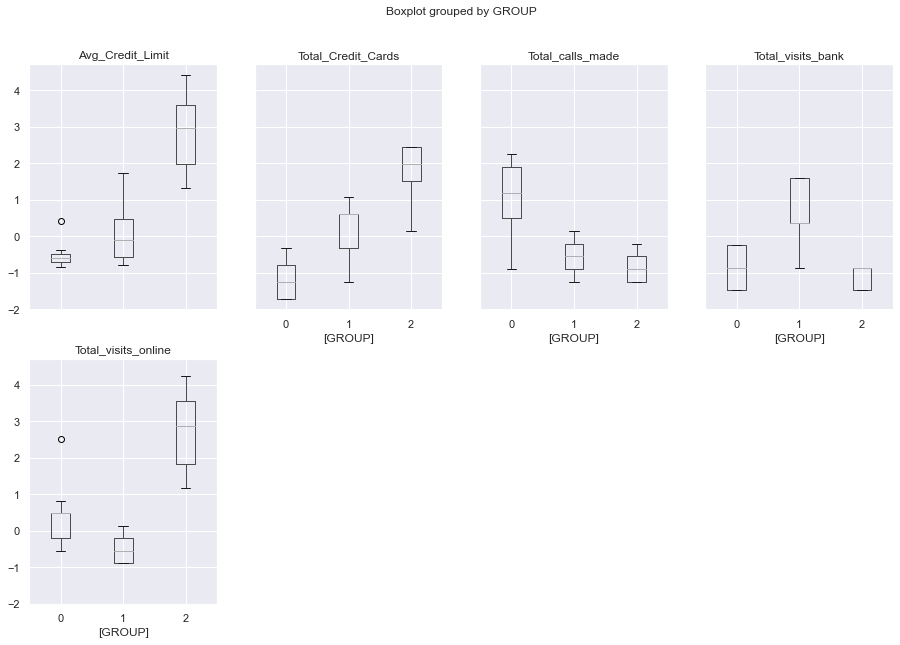

```python
creditScaledK.boxplot(by='GROUP', layout = (2,4),figsize=(15,10))
```

Now try five groups

```python
# Now let's attempt with K = 5
final_model5=KMeans(5)
final_model5.fit(creditScaledK)
prediction5=final_model5.predict(creditScaledK)

#Append the prediction
ccc_df["GROUP"] = prediction5
creditScaledK["GROUP"] = prediction5
print("Groups Assigned : \n")
ccc_df.head()
```

```
Groups Assigned :
```

| Feature Name | Sl_No | Customer Key | Avg_Credit_Limit | Total_Credit_Cards | Total_visits_bank | Total_visits_online | Total_calls_made | GROUP |
| --- | --- | --- | --- | --- | --- | --- | --- | --- |
| 0 | 1 | 87073 | 100000 | 2 | 1 | 1 | 0 | 0 |
| 1 | 2 | 38414 | 50000 | 3 | 0 | 10 | 9 | 1 |
| 2 | 3 | 17341 | 50000 | 7 | 1 | 3 | 4 | 0 |
| 3 | 4 | 40496 | 30000 | 5 | 1 | 1 | 4 | 0 |
| 4 | 5 | 47437 | 100000 | 6 | 0 | 12 | 3 | 2 |

```python
creditClust5 = ccc_df.groupby(['GROUP'])
creditClust5.mean()
```

| Feature Name GROUP | Sl_No | Customer Key | Avg_Credit_Limit | Total_Credit_Cards | Total_visits_bank | Total_visits_online | Total_calls_made |
| --- | --- | --- | --- | --- | --- | --- | --- |
| 0 | 419.627551 | 54073.484694 | 36260.204082 | 5.551020 | 2.494898 | 0.954082 | 2.061224 |
| 1 | 121.626168 | 57105.271028 | 12551.401869 | 2.476636 | 0.766355 | 3.691589 | 8.607477 |
| 2 | 611.280000 | 56708.760000 | 141040.000000 | 8.740000 | 0.600000 | 10.900000 | 1.080000 |
| 3 | 415.363158 | 55714.684211 | 31226.315789 | 5.478947 | 4.515789 | 1.010526 | 1.936842 |
| 4 | 114.410256 | 53533.829060 | 11829.059829 | 2.350427 | 1.085470 | 3.427350 | 5.282051 |

```
array([[<matplotlib.axes._subplots.AxesSubplot object at 0x1a1acbd250>,
      dtype=object)
```

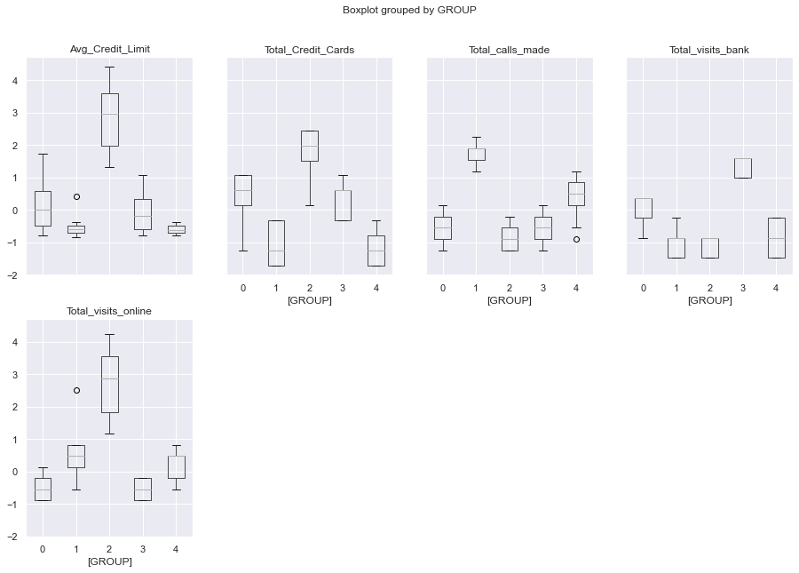

```python
creditScaledK.boxplot(by='GROUP', layout = (2,4),figsize=(15,10))
```

```python
k = KMeans(n_clusters = 5)
a = k.fit_transform(ccc_df)
a
```

```
array([[ 86222.39678918,  65676.33481507, 101103.19510586,
         42136.60516811,  59702.9595181 ],
       [ 52000.62270312, 111254.77416722,  35369.58462125,
         44349.28087125,  12445.88101763],
       [ 68901.53498866, 116990.72859687,  37740.78760592,
         65176.20950831,  26504.30313209],
       ...,
       [132483.80444264,  15225.00114656, 131606.58774754,
         91281.69458165,  83817.33401797],
       [157613.08208208,  25133.57614254, 164160.05773425,
        113835.2199665 , 116793.79214588],
       [152601.64449551,  22548.81931337, 159238.26044176,
        108843.00718537, 111927.55316658]])
```

## Execute hierarchical clustering (with different linkages) with the help of dendrogram and cophenetic coeff. Analyse clusters formed using boxplot

```python
credit = pd.read_excel('Credit Card Customer Data.xlsx')# reload the data
creditAttrH=credit.iloc[:,2:]
creditAttrH.head()
```

|  | Avg_Credit_Limit | Total_Credit_Cards | Total_visits_bank | Total_visits_online | Total_calls_made |
| --- | --- | --- | --- | --- | --- |
| 0 | 100000 | 2 | 1 | 1 | 0 |
| 1 | 50000 | 3 | 0 | 10 | 9 |
| 2 | 50000 | 7 | 1 | 3 | 4 |
| 3 | 30000 | 5 | 1 | 1 | 4 |
| 4 | 100000 | 6 | 0 | 12 | 3 |

```python
creditScaled_H=creditAttrH.apply(zscore)# rescale the data
creditScaled_H.head()
```

|  | Avg_Credit_Limit | Total_Credit_Cards | Total_visits_bank | Total_visits_online | Total_calls_made |
| --- | --- | --- | --- | --- | --- |
| 0 | 1.740187 | -1.249225 | -0.860451 | -0.547490 | -1.251537 |
| 1 | 0.410293 | -0.787585 | -1.473731 | 2.520519 | 1.891859 |
| 2 | 0.410293 | 1.058973 | -0.860451 | 0.134290 | 0.145528 |
| 3 | -0.121665 | 0.135694 | -0.860451 | -0.547490 | 0.145528 |
| 4 | 1.740187 | 0.597334 | -1.473731 | 3.202298 | -0.203739 |

```python
from sklearn.cluster import AgglomerativeClustering
model = AgglomerativeClustering(n_clusters=3, affinity='euclidean',  linkage='average')
```

```python
model.fit(creditScaled_H)
```

```
AgglomerativeClustering(affinity='euclidean', compute_full_tree='auto',
                        connectivity=None, distance_threshold=None,
                        linkage='average', memory=None, n_clusters=3)
```

```python
creditAttrH['labels'] = model.labels_
creditScaled_H['labels'] = model.labels_
credit['labels'] = model.labels_
creditAttrH.head(10)
```

|  | Avg_Credit_Limit | Total_Credit_Cards | Total_visits_bank | Total_visits_online | Total_calls_made | labels |
| --- | --- | --- | --- | --- | --- | --- |
| 0 | 100000 | 2 | 1 | 1 | 0 | 0 |
| 1 | 50000 | 3 | 0 | 10 | 9 | 2 |
| 2 | 50000 | 7 | 1 | 3 | 4 | 0 |
| 3 | 30000 | 5 | 1 | 1 | 4 | 0 |
| 4 | 100000 | 6 | 0 | 12 | 3 | 1 |
| 5 | 20000 | 3 | 0 | 1 | 8 | 2 |
| 6 | 100000 | 5 | 0 | 11 | 2 | 1 |
| 7 | 15000 | 3 | 0 | 1 | 1 | 2 |
| 8 | 5000 | 2 | 0 | 2 | 2 | 2 |
| 9 | 3000 | 4 | 0 | 1 | 7 | 2 |

```python
creditClustH = creditAttrH.groupby(['labels'])
creditClustH.mean()
```

| labels | Avg_Credit_Limit | Total_Credit_Cards | Total_visits_bank | Total_visits_online | Total_calls_made |
| --- | --- | --- | --- | --- | --- |
| 0 | 33713.178295 | 5.511628 | 3.485788 | 0.984496 | 2.005168 |
| 1 | 141040.000000 | 8.740000 | 0.600000 | 10.900000 | 1.080000 |
| 2 | 12197.309417 | 2.403587 | 0.928251 | 3.560538 | 6.883408 |

```
array([[<matplotlib.axes._subplots.AxesSubplot object at 0x1a1ad6ad50>,
      dtype=object)
```

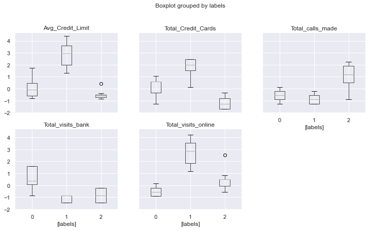

```python
creditScaled_H.boxplot(by='labels', layout = (3,3), figsize=(12,10))
```

```python
from scipy.cluster.hierarchy import cophenet, dendrogram, linkage
```

```python
from scipy.spatial.distance import pdist  #Pairwise distribution between data points
```

```python
# cophenet index is a measure of the correlation between the distance of points in feature space and distance on dendrogram
# closer it is to 1, the better is the clustering

Z_avg = linkage(creditScaled_H, metric='euclidean', method='average')
c_avg, coph_dists = cophenet(Z_avg , pdist(creditScaled_H))

c_avg
```

```
0.9252387749820263
```

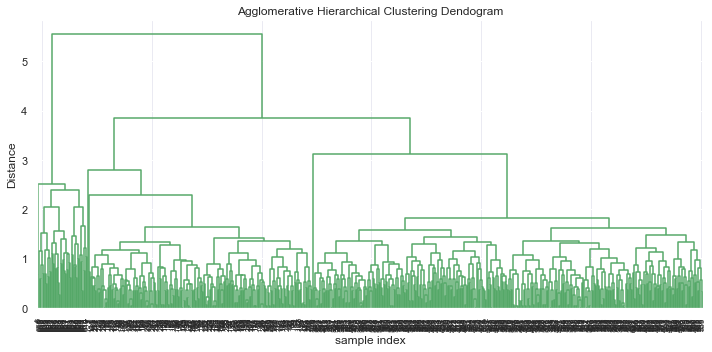

```python
plt.figure(figsize=(10, 5))
plt.title('Agglomerative Hierarchical Clustering Dendogram')
plt.xlabel('sample index')
plt.ylabel('Distance')
dendrogram(Z_avg, leaf_rotation=90.,color_threshold = 40, leaf_font_size=8. )
plt.tight_layout()
```

```python
# Change method hyperparameter to "complete"

Z_comp = linkage(creditScaled_H, metric='euclidean', method='complete')
c_comp, coph_dists = cophenet(Z_comp , pdist(creditScaled_H))

c_comp
```

```
0.9181204166982053
```

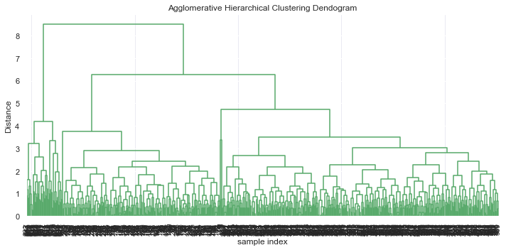

```python
plt.figure(figsize=(10, 5))
plt.title('Agglomerative Hierarchical Clustering Dendogram')
plt.xlabel('sample index')
plt.ylabel('Distance')
dendrogram(Z_comp, leaf_rotation=90.,color_threshold=90,  leaf_font_size=10. )
plt.tight_layout()
```

```python
# Change method hyperparameter to "ward"

Z_ward = linkage(creditScaled_H, metric='euclidean', method='ward')
c_ward, coph_dists = cophenet(Z_ward, pdist(creditScaled_H))

c_ward
```

```
0.8170227112271451
```

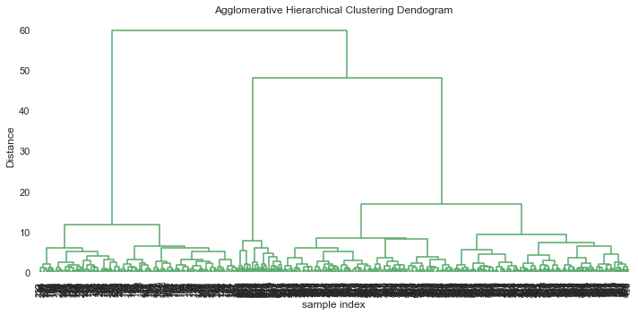

```python
plt.figure(figsize=(10, 5))
plt.title('Agglomerative Hierarchical Clustering Dendogram')
plt.xlabel('sample index')
plt.ylabel('Distance')
dendrogram(Z_ward, leaf_rotation=90.,color_threshold=90,  leaf_font_size=10. )
plt.tight_layout()
```

### Calculate average silhouette score for both methods

```python
from sklearn.metrics import silhouette_score
```

```python
clusters=range(2,10)
meanSC=[]
creditAttr=ccc_df.iloc[:,2:]
creditScaled=creditAttr.apply(zscore)

#The following loop calculate the silouette score for K-means clustering ...
#           with different number of clusters
for k in clusters:
    model=KMeans(n_clusters=k)
    model.fit(creditScaled)
    prediction=model.predict(creditScaled)
    SC=silhouette_score(creditScaled, prediction)
    print('Silhouette Score(n=',k,'):', SC)
```

```
Silhouette Score(n= 2 ): 0.3703690488911945
Silhouette Score(n= 3 ): 0.45519453780521385
Silhouette Score(n= 4 ): 0.4743422048610454
Silhouette Score(n= 5 ): 0.5106609160770046
Silhouette Score(n= 6 ): 0.43017408573768423
Silhouette Score(n= 7 ): 0.35234196168637916
Silhouette Score(n= 8 ): 0.3048370430592631
Silhouette Score(n= 9 ): 0.3211229495184026
```

```python
##The following loop calculate the silouette score for hierarchical clustering ...
#     with different number of clusters
creditAttr2=creditAttr

for k in clusters:
    model = AgglomerativeClustering(n_clusters=k, affinity='euclidean',  linkage='average')
    model.fit(creditScaled_H)
    creditAttr2['labels'] = model.labels_
    creditScaled_H['labels'] = model.labels_

    SC=silhouette_score(creditScaled_H, model.labels_)
    print('Silhouette Score(n=',k,'):', SC)
```

```
Silhouette Score(n= 2 ): 0.5778491354897204
Silhouette Score(n= 3 ): 0.5909904735965409
Silhouette Score(n= 4 ): 0.5376007389773523
Silhouette Score(n= 5 ): 0.5083892997628973
Silhouette Score(n= 6 ): 0.521611400654466
Silhouette Score(n= 7 ): 0.5404795126267791
Silhouette Score(n= 8 ): 0.5586418155475954
Silhouette Score(n= 9 ): 0.5827287097516507
```

```python
ccc_df.head()
```

| Feature Name | Sl_No | Customer Key | Avg_Credit_Limit | Total_Credit_Cards | Total_visits_bank | Total_visits_online | Total_calls_made | GROUP |
| --- | --- | --- | --- | --- | --- | --- | --- | --- |
| 0 | 1 | 87073 | 100000 | 2 | 1 | 1 | 0 | 0 |
| 1 | 2 | 38414 | 50000 | 3 | 0 | 10 | 9 | 1 |
| 2 | 3 | 17341 | 50000 | 7 | 1 | 3 | 4 | 0 |
| 3 | 4 | 40496 | 30000 | 5 | 1 | 1 | 4 | 0 |
| 4 | 5 | 47437 | 100000 | 6 | 0 | 12 | 3 | 2 |

```python
creditAttr2.head()
```

| Feature Name | Avg_Credit_Limit | Total_Credit_Cards | Total_visits_bank | Total_visits_online | Total_calls_made | GROUP | labels |
| --- | --- | --- | --- | --- | --- | --- | --- |
| 0 | 100000 | 2 | 1 | 1 | 0 | 0 | 5 |
| 1 | 50000 | 3 | 0 | 10 | 9 | 1 | 7 |
| 2 | 50000 | 7 | 1 | 3 | 4 | 0 | 1 |
| 3 | 30000 | 5 | 1 | 1 | 4 | 0 | 1 |
| 4 | 100000 | 6 | 0 | 12 | 3 | 2 | 4 |

```python
ccc_df.shape
```

[output not shown]

```python
creditAttr3.shape
```

[output not shown]

### Compare K-means clusters with Hierarchical clusters.

```python
#Redo the K-means clustering for N of clusters = 3
ccc_df = pd.read_excel('Credit Card Customer Data.xlsx')

creditAttrK=ccc_df.iloc[:,2:]
creditScaledK=creditAttrK.apply(zscore)

final_model3=KMeans(3)
final_model3.fit(creditScaledK)
prediction3=final_model3.predict(creditScaledK)

#Append the prediction
ccc_df["GROUP"] = prediction3
creditScaledK3["GROUP"] = prediction3
print("Groups Assigned : \n")
ccc_df.head()
```

```
Groups Assigned :
```

|  | Sl_No | Customer Key | Avg_Credit_Limit | Total_Credit_Cards | Total_visits_bank | Total_visits_online | Total_calls_made | GROUP |
| --- | --- | --- | --- | --- | --- | --- | --- | --- |
| 0 | 1 | 87073 | 100000 | 2 | 1 | 1 | 0 | 0 |
| 1 | 2 | 38414 | 50000 | 3 | 0 | 10 | 9 | 1 |
| 2 | 3 | 17341 | 50000 | 7 | 1 | 3 | 4 | 0 |
| 3 | 4 | 40496 | 30000 | 5 | 1 | 1 | 4 | 0 |
| 4 | 5 | 47437 | 100000 | 6 | 0 | 12 | 3 | 2 |

```python
#Redo the hierarchical clustering for N of clusters = 3
credit = pd.read_excel('Credit Card Customer Data.xlsx')
creditAttrH=ccc_df.iloc[:,2:]
creditScaledH=creditAttrH.apply(zscore)
model = AgglomerativeClustering(n_clusters=3, affinity='euclidean',  linkage='average')
model.fit(creditScaledH)
creditAttrH['labels'] = model.labels_
creditScaledH['labels'] = model.labels_
credit['labels'] = model.labels_
credit.head()
```

|  | Sl_No | Customer Key | Avg_Credit_Limit | Total_Credit_Cards | Total_visits_bank | Total_visits_online | Total_calls_made | labels |
| --- | --- | --- | --- | --- | --- | --- | --- | --- |
| 0 | 1 | 87073 | 100000 | 2 | 1 | 1 | 0 | 0 |
| 1 | 2 | 38414 | 50000 | 3 | 0 | 10 | 9 | 2 |
| 2 | 3 | 17341 | 50000 | 7 | 1 | 3 | 4 | 0 |
| 3 | 4 | 40496 | 30000 | 5 | 1 | 1 | 4 | 0 |
| 4 | 5 | 47437 | 100000 | 6 | 0 | 12 | 3 | 1 |

```python
### Put together a dataframe to compare the two clustering results

comp_df1=ccc_df.iloc[:,[0,1,7]]
#comp_df=comp_df.drop(comp_df.columns[cols],axis=1,inplace=True)
comp_df1.rename(columns={'GROUP':'K_means_result'}, inplace=True)
comp_df2=credit.iloc[:,[0,1,7]]
comp_df2.rename(columns={'labels':'Hierarchical_result'}, inplace=True)
```

```python
#comp_df=comp_df1.set_index('Customer Key').join(comp_df2.set_index('Customer Key'))
comp_df=comp_df1
comp_df['Hierarchical_result']=comp_df2['Hierarchical_result']
comp_df.head(5)
#The dataframe named "comp_df" shows the clustering results from two method for each customer
```

|  | Sl_No | Customer Key | K_means_result | Hierarchical_result |
| --- | --- | --- | --- | --- |
| 0 | 1 | 87073 | 0 | 0 |
| 1 | 2 | 38414 | 1 | 2 |
| 2 | 3 | 17341 | 0 | 0 |
| 3 | 4 | 40496 | 0 | 0 |
| 4 | 5 | 47437 | 2 | 1 |

```python
#count the number of records that two of the clustering methods assign to the same group
sum(comp_df['K_means_result']==comp_df['Hierarchical_result'])
```

```
386
```

```python
comp_df.head(20)
```

|  | Sl_No | Customer Key | K_means_result | Hierarchical_result |
| --- | --- | --- | --- | --- |
| 0 | 1 | 87073 | 0 | 0 |
| 1 | 2 | 38414 | 1 | 2 |
| 2 | 3 | 17341 | 0 | 0 |
| 3 | 4 | 40496 | 0 | 0 |
| 4 | 5 | 47437 | 2 | 1 |
| 5 | 6 | 58634 | 1 | 2 |
| 6 | 7 | 48370 | 2 | 1 |
| 7 | 8 | 37376 | 1 | 2 |
| 8 | 9 | 82490 | 1 | 2 |
| 9 | 10 | 44770 | 1 | 2 |
| 10 | 11 | 52741 | 1 | 2 |
| 11 | 12 | 52326 | 1 | 2 |
| 12 | 13 | 92503 | 1 | 2 |
| 13 | 14 | 25084 | 1 | 2 |
| 14 | 15 | 68517 | 1 | 2 |
| 15 | 16 | 55196 | 1 | 2 |
| 16 | 17 | 62617 | 1 | 2 |
| 17 | 18 | 96463 | 1 | 2 |
| 18 | 19 | 39137 | 1 | 2 |
| 19 | 20 | 14309 | 1 | 2 |

```python
#Add a new column to the dataframe and relabel the group number of one method
#This is hard coding, the codes needs to be changed evertime the clustering has repeated
comp_df['K_means_new_result']=comp_df['K_means_result']
comp_df.loc[comp_df['K_means_result'] ==1,'K_means_new_result'] = 2
comp_df.loc[comp_df['K_means_result'] ==2,'K_means_new_result'] = 1
#comp_df.loc[comp_df['K_means_result'] ==0,'K_means_new_result'] = 2
```

```python
sum(comp_df['K_means_new_result']==comp_df['Hierarchical_result'])*100/comp_df.shape[0]
```

```
100.0
```

# They privided the same clustering results

```python
#Redo the K-means clustering for N of clusters = 5
ccc_df = pd.read_excel('Credit Card Customer Data.xlsx')

creditAttrK=ccc_df.iloc[:,2:]
creditScaledK=creditAttrK.apply(zscore)

final_model3=KMeans(5)
final_model3.fit(creditScaledK)
prediction3=final_model3.predict(creditScaledK)

#Append the prediction
ccc_df["GROUP"] = prediction3
creditScaledK3["GROUP"] = prediction3
print("Groups Assigned : \n")
ccc_df.head()
```

```
Groups Assigned :
```

|  | Sl_No | Customer Key | Avg_Credit_Limit | Total_Credit_Cards | Total_visits_bank | Total_visits_online | Total_calls_made | GROUP |
| --- | --- | --- | --- | --- | --- | --- | --- | --- |
| 0 | 1 | 87073 | 100000 | 2 | 1 | 1 | 0 | 0 |
| 1 | 2 | 38414 | 50000 | 3 | 0 | 10 | 9 | 3 |
| 2 | 3 | 17341 | 50000 | 7 | 1 | 3 | 4 | 0 |
| 3 | 4 | 40496 | 30000 | 5 | 1 | 1 | 4 | 0 |
| 4 | 5 | 47437 | 100000 | 6 | 0 | 12 | 3 | 2 |

```python
#Redo the hierarchical clustering for N of clusters = 3
credit = pd.read_excel('Credit Card Customer Data.xlsx')
creditAttrH=ccc_df.iloc[:,2:]
creditScaledH=creditAttrH.apply(zscore)
model = AgglomerativeClustering(n_clusters=5, affinity='euclidean',  linkage='average')
model.fit(creditScaledH)
creditAttrH['labels'] = model.labels_
creditScaledH['labels'] = model.labels_
credit['labels'] = model.labels_
credit.head()
```

|  | Sl_No | Customer Key | Avg_Credit_Limit | Total_Credit_Cards | Total_visits_bank | Total_visits_online | Total_calls_made | labels |
| --- | --- | --- | --- | --- | --- | --- | --- | --- |
| 0 | 1 | 87073 | 100000 | 2 | 1 | 1 | 0 | 3 |
| 1 | 2 | 38414 | 50000 | 3 | 0 | 10 | 9 | 4 |
| 2 | 3 | 17341 | 50000 | 7 | 1 | 3 | 4 | 2 |
| 3 | 4 | 40496 | 30000 | 5 | 1 | 1 | 4 | 2 |
| 4 | 5 | 47437 | 100000 | 6 | 0 | 12 | 3 | 0 |

```python
### Put together a dataframe to compare the two clustering results

comp_df1=ccc_df.iloc[:,[0,1,7]]
#comp_df=comp_df.drop(comp_df.columns[cols],axis=1,inplace=True)
comp_df1.rename(columns={'GROUP':'K_means_result'}, inplace=True)
comp_df2=credit.iloc[:,[0,1,7]]
comp_df2.rename(columns={'labels':'Hierarchical_result'}, inplace=True)
```

```python
comp_df=comp_df1
comp_df['Hierarchical_result']=comp_df2['Hierarchical_result']
comp_df.head(5)
```

|  | Sl_No | Customer Key | K_means_result | Hierarchical_result |
| --- | --- | --- | --- | --- |
| 0 | 1 | 87073 | 0 | 3 |
| 1 | 2 | 38414 | 3 | 4 |
| 2 | 3 | 17341 | 0 | 2 |
| 3 | 4 | 40496 | 0 | 2 |
| 4 | 5 | 47437 | 2 | 0 |

```python
#count the number of records that two of the clustering methods assign to the same group
sum(comp_df['K_means_result']==comp_df['Hierarchical_result'])
```

```
0
```

```python
from collections import defaultdict
#This paragraph of code is to compare the difference of two clustering methods
idSize = comp_df.shape[0]
groupOne = comp_df['K_means_result'].tolist()
groupTwo = comp_df['Hierarchical_result'].tolist()

distanceMatrixOne = defaultdict(dict)
distanceMatrixTwo = defaultdict(dict)
for i in range(idSize):
    for j in range(i+1, idSize):
        if groupOne[i] == groupOne[j]:
            distanceMatrixOne[i][j] = 0
        else:
            distanceMatrixOne[i][j] = 1
        if groupTwo[i] == groupTwo[j]:
            distanceMatrixTwo[i][j] = 0
        else:
            distanceMatrixTwo[i][j] = 1

sumDiff = 0
for i in range(idSize):
    for j in range(i+1, idSize):
        if distanceMatrixOne[i][j] != distanceMatrixTwo[i][j]:
            sumDiff += 1
print(sumDiff)
```

```
49753
```

```python
import operator as op
from functools import reduce

def ncr(n, r):
    r = min(r, n-r)
    numer = reduce(op.mul, range(n, n-r, -1), 1)
    denom = reduce(op.mul, range(1, r+1), 1)
    return numer // denom  # or / in Python 2
ratio=sumDiff/ncr(idSize,2)#This give the ratio of different
print("The ratio of different clustering of the two methods are: ",ratio)
#This gives the cluster difference of two methods when n_clusters = 5
```

```
The ratio of different clustering of the two methods are:  0.22878098128477492
```

```python
from IPython.core.interactiveshell import InteractiveShell
InteractiveShell.ast_node_interactivity = "all"

def ClusterIndicesNumpy(clustNum, labels_array): #numpy
    return np.where(labels_array == clustNum)[0]

def ClusterIndicesComp(clustNum, labels_array): #list comprehension
    return np.array([i for i, x in enumerate(labels_array) if x == clustNum])
#ClusterIndicesNumpy(0, model.labels_)
# ClusterIndicesNumpy(1, model.labels_)
# ClusterIndicesNumpy(2, model.labels_)
# ClusterIndicesNumpy(3, model.labels_)
# ClusterIndicesNumpy(4, model.labels_)
```

[output not shown]

Overall, the two method group the data the into the same results when chose number_clusters at 3

### Analyze the clusters formed, tell us how is one cluster different from another and answer all the key questions.

As analayzed in the previous section, it's best to cluster the customers into three segments

```python
#Rerun the K-means clustering at n_clusters = 3
creditScaledK3=creditScaledK
final_model3=KMeans(3)
final_model3.fit(creditScaledK3)
prediction3=final_model3.predict(creditScaledK3)

#Append the prediction
ccc_df["GROUP"] = prediction3
creditScaledK3["GROUP"] = prediction3
print("Groups Assigned : \n")
```

```
KMeans(algorithm='auto', copy_x=True, init='k-means++', max_iter=300,
       n_clusters=3, n_init=10, n_jobs=None, precompute_distances='auto',
       random_state=None, tol=0.0001, verbose=0)
```

```
Groups Assigned :
```

```python
creditClustK = ccc_df.groupby(['GROUP'])
creditClustK.mean()
#Print out the clustering results based on K-means clustering
```

| GROUP | Sl_No | Customer Key | Avg_Credit_Limit | Total_Credit_Cards | Total_visits_bank | Total_visits_online | Total_calls_made |
| --- | --- | --- | --- | --- | --- | --- | --- |
| 0 | 417.528497 | 54881.329016 | 33782.383420 | 5.515544 | 3.489637 | 0.981865 | 2.000000 |
| 1 | 117.857143 | 55239.830357 | 12174.107143 | 2.410714 | 0.933036 | 3.553571 | 6.870536 |
| 2 | 611.280000 | 56708.760000 | 141040.000000 | 8.740000 | 0.600000 | 10.900000 | 1.080000 |

```python
from collections import Counter
print(Counter(final_model3.labels_))#print the number of customers in each cluster by K-means
```

```
Counter({0: 386, 1: 224, 2: 50})
```

```python
#Rerun the hierarachial clustering at n_clusters = 3
model = AgglomerativeClustering(n_clusters=3, affinity='euclidean',  linkage='average')
credit = pd.read_excel('Credit Card Customer Data.xlsx')# reload the data
creditAttrH=credit.iloc[:,2:]
creditScaled_H=creditAttrH.apply(zscore)
model.fit(creditScaled_H)
creditAttrH['labels'] = model.labels_
creditScaled_H['labels'] = model.labels_
credit['labels'] = model.labels_
creditClustH = creditAttrH.groupby(['labels'])
creditClustH.mean()#Print out the clustering results based on hieraricial clustering
```

```
AgglomerativeClustering(affinity='euclidean', compute_full_tree='auto',
                        connectivity=None, distance_threshold=None,
                        linkage='average', memory=None, n_clusters=3)
```

| labels | Avg_Credit_Limit | Total_Credit_Cards | Total_visits_bank | Total_visits_online | Total_calls_made |
| --- | --- | --- | --- | --- | --- |
| 0 | 33713.178295 | 5.511628 | 3.485788 | 0.984496 | 2.005168 |
| 1 | 141040.000000 | 8.740000 | 0.600000 | 10.900000 | 1.080000 |
| 2 | 12197.309417 | 2.403587 | 0.928251 | 3.560538 | 6.883408 |

```python
print(Counter(model.labels_))#print the number of customers in each cluster by hierachical
```

```
Counter({0: 387, 2: 223, 1: 50})
```

The two clustering methods would group the customers into three identical (or extremely similar) clusters, of course with a different cluster label. Because when you run K-means clustering, the label key (0,1,2) is randomly assigned and would change each time you rerun the model.

We can have the following analysis based on the table above:

The group of customers with very high average credit limit (also the most credit cards) and a lot of online logins but very few onsite bank vist is in one group;

The customers with the lowest average credit limit would have the least credit cards and the most calls, totals visits, both online and onsite, lie in middle;

It is immaginable that customers with the lowest credit limit would need to call the bank more often to resolve issue with their credit or more complaints. The group of customers with the most credit limits and credit cards would need to spend more time to take care of their accounts therefore more online visits. This would leave them less need to go to the bank physically.

I would focus on the group with lowest credit limit and least credit cards to offer them banker appointments or call backs to take care of their issues that they have to called in. Offer them new credit card with higher credit limit might be an option, given good credit score.

I would also offer the group with highest credit limit onsite appointments to explore other business. This group has the least number of customers therefore is more feasible to do that. These customers made the least onsite visits to the bank so an appointment offering might attract them.

I would offer the group with the middle credit limit and the least online visits some online resources and maybe more guidance. It could be the group of elder people that are not familiar with online operation. They have enough credit limit and credit cards but just could not make the best use of online resources due to habits or generational gap.

#### Conclusion:

The difference between the three groups/clusters are very distinctive and give us a lot of insights. We can obtain a lot of insights from the clustering models.